# In the Heat of Protest

Mason Meeks

Since the mid-2010s, it feels as though our world and society has changed drastically, especially with how we engage politically. Using data from the Crowd Counting Consortium, I will be investigating the ebb and flow of protests from 2020 to 2022. Specifically, I will be using protest data from July of each of these years. The primary reason for using a singular month from each year is that July is directly in the middle of the time of year in which the majority of the year's protests happen. Therefore, the use of one month from each year will be simplier and still give me plenty of data.

I will also be using hate crime data from the FBI's Crime Data Explorer which will allow me to find correlations and create models to investigate the connection between a particular states's protest-based political affiliation, protest activity, and hate crime frequency. Lastly, I will be using U.S. Census Bureau data to control for population.

The github page for this notebook can be found [here](https://mmeekstu.github.io/data-science/)

```python
# clone the course repository, change to right directory, and import libraries.
%cd /content
!git clone https://github.com/mmeekstu/data_science.git
%cd /content/data_science/'Project Data'/'July Data'
import pandas as pd
import numpy as np
import matplotlib.pyplot as plt
import seaborn as sns
pd.set_option('display.max_columns', None)
```

```
/content
Cloning into 'data_science'...
remote: Enumerating objects: 212, done.
remote: Counting objects: 100% (78/78), done.
remote: Compressing objects: 100% (54/54), done.
remote: Total 212 (delta 30), reused 66 (delta 24), pack-reused 134
Receiving objects: 100% (212/212), 18.75 MiB | 18.34 MiB/s, done.
Resolving deltas: 100% (89/89), done.
/content/data_science/Project Data/July Data
```

# Protest Data

This data comes from the Crowd Counting Consortium ([found here](https://sites.google.com/view/crowdcountingconsortium/view-download-the-data?authuser=0)) which analyzes every protest, demonstration, rally, vigil, etc. throughout the U.S. The creators of this data have coded in many aspects of protests including its location, size, claim, groups, interactions among protesters, interactions among police, and many others. I chose this data because it should give me an abundance of information that will allow me to ask and potentially answer many types of questions. The initial question I hope to investigate with this data is how the frequency of protests and number of protesters have changed since 2020. With major elections, COVID, and massive public responses to policies and governmental actions, I expect to find a lot of interesting statistics that will shape the overall goal of this project.

## ETL

```python
# Reading in csv files
df_2020 = pd.read_csv('Crowd Estimates July 2020 - Tally.csv')
df_2021 = pd.read_csv('Crowd Estimates July 2021 - Tally.csv')
df_2022 = pd.read_csv('Crowd Estimates July 2022 - Tally.csv')
```

After reading the csv files in, I am going to add a year column to each with their corresponding year. This will make grouping them quick and simple later on.

```python
# Adding a year column to each
df_2020['Year'] = 2020
df_2021['Year'] = 2021
df_2022['Year'] = 2022
```

```python
# Creating a list for easy access
df_list = list([df_2020, df_2021, df_2022])
```

Now for a quick display of the first row of each file. This will show how messy or neat the data is, and allow me to understand where I need to start organizing and tidying.

```python
for df in df_list:
  display(df.head(1))
```

|  | CityTown | Location | County | StateTerritory | Country | Date | EstimateText | EstimateLow | BestGuess | EstimateHigh | AdjustedLow | AdjustedHigh | Actor | Claim | Pro(2)/Anti(1) | EventType | ReportedArrests | ReportedParticipantInjuries | ReportedPoliceInjuries | ReportedPropertyDamage | TownsCities | Events | MacroEvent | Misc. | Source1 | Source2 | Source3 | Source4 | Source5 | … |
| --- | --- | --- | --- | --- | --- | --- | --- | --- | --- | --- | --- | --- | --- | --- | --- | --- | --- | --- | --- | --- | --- | --- | --- | --- | --- | --- | --- | --- | --- | --- |
| 0 | Ashland | Memorial Park; streets of Ashland; Highway 13 ... | NaN | WI | US | 2020-07-01 | NaN | NaN | NaN | NaN | NaN | NaN | water protectors | against recloation of Enbridge Line 5 Pipeline... | 1 | protest | 0 | 0 | 0.0 | 0.0 | 1 | 1 | NaN | NaN | https://kbjr6.com/2020/07/01/protesters-march-... | NaN | NaN | NaN | NaN | … |

|  | date | locality | state | location | title | size_text | size_low | size_high | organizations | participants | claims | valence | event_type | police_measures | participant_measures | police_injuries | participant_injuries | arrests | property_damage | police_deaths | participant_deaths | macroevent | notes | coder | source1 | source2 | source3 | source4 | source5 | … |
| --- | --- | --- | --- | --- | --- | --- | --- | --- | --- | --- | --- | --- | --- | --- | --- | --- | --- | --- | --- | --- | --- | --- | --- | --- | --- | --- | --- | --- | --- | --- |
| 0 | 2021-07-01 | Addison | IL | Portillo's Food Service | NaN | 17 | 17.0 | 17.0 | Arise Chicago | workers | for better working conditions and higher pay f... | 0.0 | strike; picket | NaN | NaN | NaN | NaN | NaN | NaN | NaN | NaN | NaN | NaN | NaN | https://chicago.suntimes.com/2021/7/2/22561028... | NaN | NaN | NaN | NaN | … |

|  | date | locality | state | location | title | size_text | size_low | size_high | organizations | participants | claims | valence | event_type | police_measures | participant_measures | police_injuries | participant_injuries | arrests | property_damage | police_deaths | participant_deaths | macroevent | notes | coder | source1 | source2 | source3 | source4 | source5 | … |
| --- | --- | --- | --- | --- | --- | --- | --- | --- | --- | --- | --- | --- | --- | --- | --- | --- | --- | --- | --- | --- | --- | --- | --- | --- | --- | --- | --- | --- | --- | --- |
| 0 | 2022-07-01 | Akron | OH | Harold K. Stubbs Justice Center | NaN | about 20 | 20.0 | 20.0 | The Freedom BLOC | NaN | for justice for Jayland Walker, against police... | 1.0 | protest | NaN | conversation with counter-protester | NaN | NaN | NaN | NaN | NaN | NaN | 20220701-akron-jaylandwalker | NaN | NaN | https://twitter.com/sahrasulaiman/status/15431... | https://fox8.com/news/elected-officials-callin... | https://www.wkyc.com/article/news/local/akron/... | https://www.beaconjournal.com/story/news/2022/... | https://www.instagram.com/p/Cfcmqv6JPtD/ | … |

There are a lot of usesless columns that need to be dropped. Also, this data is quite messy and is not the most consistently titled throughout the years. I am just going to run some for loops to iterate through the columns to drop what I don't want.

```python
# Dropping a lot of data that will not be needed for the project
for (cName, cData) in df_2020.items():
    if ("source" in cName) | ('Source' in cName) | ('macroevent' in cName) | ('MacroEvent' in cName) | ('Misc.' in cName) | ('Unnamed' in cName) | ('notes' in cName) | ('coder' in cName) | ('TownsCities' in cName) | ('Events' in cName) | ('BestGuess' in cName) | ('AdjustedLow' in cName) | ('AdjustedHigh' in cName) | ('EstimateText' in cName) | ('County' in cName) | ('size_text' in cName) | ('title' in cName):
      df_2020 = df_2020.drop(columns = cName)
for (cName, cData) in df_2021.items():
    if ("source" in cName) | ('Source' in cName) | ('macroevent' in cName) | ('MacroEvent' in cName) | ('Misc.' in cName) | ('Unnamed' in cName) | ('notes' in cName) | ('coder' in cName) | ('TownsCities' in cName) | ('Events' in cName) | ('BestGuess' in cName) | ('AdjustedLow' in cName) | ('AdjustedHigh' in cName) | ('EstimateText' in cName) | ('County' in cName) | ('size_text' in cName) | ('title' in cName):
      df_2021 = df_2021.drop(columns = cName)
for (cName, cData) in df_2022.items():
    if ("source" in cName) | ('Source' in cName) | ('macroevent' in cName) | ('MacroEvent' in cName) | ('Misc.' in cName) | ('Unnamed' in cName) | ('notes' in cName) | ('coder' in cName) | ('TownsCities' in cName) | ('Events' in cName) | ('BestGuess' in cName) | ('AdjustedLow' in cName) | ('AdjustedHigh' in cName) | ('EstimateText' in cName) | ('County' in cName) | ('size_text' in cName) | ('title' in cName):
      df_2022 = df_2022.drop(columns = cName)
```

```python
# Re-estabilshing the list
df_list = list([df_2020, df_2021, df_2022])
```

```python
# Let's see what we have now
for df in df_list:
  display(df.head(1))
```

|  | CityTown | Location | StateTerritory | Country | Date | EstimateLow | EstimateHigh | Actor | Claim | Pro(2)/Anti(1) | EventType | ReportedArrests | ReportedParticipantInjuries | ReportedPoliceInjuries | ReportedPropertyDamage | Year |
| --- | --- | --- | --- | --- | --- | --- | --- | --- | --- | --- | --- | --- | --- | --- | --- | --- |
| 0 | Ashland | Memorial Park; streets of Ashland; Highway 13 ... | WI | US | 2020-07-01 | NaN | NaN | water protectors | against recloation of Enbridge Line 5 Pipeline... | 1 | protest | 0 | 0 | 0.0 | 0.0 | 2020 |

|  | date | locality | state | location | size_low | size_high | organizations | participants | claims | valence | event_type | police_measures | participant_measures | police_injuries | participant_injuries | arrests | property_damage | police_deaths | participant_deaths | Year |
| --- | --- | --- | --- | --- | --- | --- | --- | --- | --- | --- | --- | --- | --- | --- | --- | --- | --- | --- | --- | --- |
| 0 | 2021-07-01 | Addison | IL | Portillo's Food Service | 17.0 | 17.0 | Arise Chicago | workers | for better working conditions and higher pay f... | 0.0 | strike; picket | NaN | NaN | NaN | NaN | NaN | NaN | NaN | NaN | 2021 |

|  | date | locality | state | location | size_low | size_high | organizations | participants | claims | valence | event_type | police_measures | participant_measures | police_injuries | participant_injuries | arrests | property_damage | police_deaths | participant_deaths | Year |
| --- | --- | --- | --- | --- | --- | --- | --- | --- | --- | --- | --- | --- | --- | --- | --- | --- | --- | --- | --- | --- |
| 0 | 2022-07-01 | Akron | OH | Harold K. Stubbs Justice Center | 20.0 | 20.0 | The Freedom BLOC | NaN | for justice for Jayland Walker, against police... | 1.0 | protest | NaN | conversation with counter-protester | NaN | NaN | NaN | NaN | NaN | NaN | 2022 |

It is defintely already more manageable and organized. However, there are a lot of inconsistencies throughout the naming. There seemed to be a large change in 2021 with how the investigators coded the data. I will go ahead and make the names more consistent.

```python
# Renamming inconsistent data
df_2020 = df_2020.rename(columns={"CityTown": "City", "StateTerritory": "State", 'Actor': 'Actors', 'Pro(2)/Anti(1)': 'Political Affiliation'})
df_2021 = df_2021.rename(columns={'date': 'Date', 'locality': 'City', 'location': 'Location', 'state': 'State', 'size_low': 'EstimateLow', 'size_high': 'EstimateHigh', 'claims': 'Claim', 'event_type': 'EventType', 'participants': 'Actors', 'valence': 'Political Affiliation', 'police_injuries': 'ReportedPoliceInjuries', 'participant_injuries': 'ReportedParticipantInjuries', 'arrests': 'ReportedArrests', 'property_damage': 'ReportedPropertyDamage'})
df_2022 = df_2022.rename(columns={'date': 'Date', 'locality': 'City', 'location': 'Location', 'state': 'State', 'size_low': 'EstimateLow', 'size_high': 'EstimateHigh', 'claims': 'Claim', 'event_type': 'EventType', 'participants': 'Actors', 'valence': 'Political Affiliation', 'police_injuries': 'ReportedPoliceInjuries', 'participant_injuries': 'ReportedParticipantInjuries', 'arrests': 'ReportedArrests', 'property_damage': 'ReportedPropertyDamage'})
```

```python
# Re-establishing the list
df_list = list([df_2020, df_2021, df_2022])
```

```python
# Much more consistent
for df in df_list:
  display(df.head(1))
```

|  | City | Location | State | Country | Date | EstimateLow | EstimateHigh | Actors | Claim | Political Affiliation | EventType | ReportedArrests | ReportedParticipantInjuries | ReportedPoliceInjuries | ReportedPropertyDamage | Year |
| --- | --- | --- | --- | --- | --- | --- | --- | --- | --- | --- | --- | --- | --- | --- | --- | --- |
| 0 | Ashland | Memorial Park; streets of Ashland; Highway 13 ... | WI | US | 2020-07-01 | NaN | NaN | water protectors | against recloation of Enbridge Line 5 Pipeline... | 1 | protest | 0 | 0 | 0.0 | 0.0 | 2020 |

|  | Date | City | State | Location | EstimateLow | EstimateHigh | organizations | Actors | Claim | Political Affiliation | EventType | police_measures | participant_measures | ReportedPoliceInjuries | ReportedParticipantInjuries | ReportedArrests | ReportedPropertyDamage | police_deaths | participant_deaths | Year |
| --- | --- | --- | --- | --- | --- | --- | --- | --- | --- | --- | --- | --- | --- | --- | --- | --- | --- | --- | --- | --- |
| 0 | 2021-07-01 | Addison | IL | Portillo's Food Service | 17.0 | 17.0 | Arise Chicago | workers | for better working conditions and higher pay f... | 0.0 | strike; picket | NaN | NaN | NaN | NaN | NaN | NaN | NaN | NaN | 2021 |

|  | Date | City | State | Location | EstimateLow | EstimateHigh | organizations | Actors | Claim | Political Affiliation | EventType | police_measures | participant_measures | ReportedPoliceInjuries | ReportedParticipantInjuries | ReportedArrests | ReportedPropertyDamage | police_deaths | participant_deaths | Year |
| --- | --- | --- | --- | --- | --- | --- | --- | --- | --- | --- | --- | --- | --- | --- | --- | --- | --- | --- | --- | --- |
| 0 | 2022-07-01 | Akron | OH | Harold K. Stubbs Justice Center | 20.0 | 20.0 | The Freedom BLOC | NaN | for justice for Jayland Walker, against police... | 1.0 | protest | NaN | conversation with counter-protester | NaN | NaN | NaN | NaN | NaN | NaN | 2022 |

I am going to go ahead and concatenate the tables now that naming is more consistent. This will allow me to more easily manage, transform, and analyze the data.

```python
df_full = pd.concat([df_2020, df_2021, df_2022])
```

```python
# Success. Here is what the new table looks like
df_full
```

|  | City | Location | State | Country | Date | EstimateLow | EstimateHigh | Actors | Claim | Political Affiliation | EventType | ReportedArrests | ReportedParticipantInjuries | ReportedPoliceInjuries | ReportedPropertyDamage | Year | organizations | police_measures | participant_measures | police_deaths | participant_deaths |
| --- | --- | --- | --- | --- | --- | --- | --- | --- | --- | --- | --- | --- | --- | --- | --- | --- | --- | --- | --- | --- | --- |
| 0 | Ashland | Memorial Park; streets of Ashland; Highway 13 ... | WI | US | 2020-07-01 | NaN | NaN | water protectors | against recloation of Enbridge Line 5 Pipeline... | 1.0 | protest | 0 | 0 | 0.0 | 0.0 | 2020 | NaN | NaN | NaN | NaN | NaN |
| 1 | Boulevard | NaN | CA | US | 2020-07-01 | 100.0 | 100.0 | members of the Kumeyaay Tribe | against construction of border wall, against d... | 1.0 | march | NaN | NaN | NaN | NaN | 2020 | NaN | NaN | NaN | NaN | NaN |
| 2 | Brentwood | Bank of America Financial Center | CA | US | 2020-07-01 | NaN | NaN | fired employees of Terranea Resort | against firing of staff and salary cuts at Ter... | 0.0 | caravan; protest | 0 | 0 | 0.0 | 0.0 | 2020 | NaN | NaN | NaN | NaN | NaN |
| 3 | Eugene | Lane County Jail | OR | US | 2020-07-01 | 150.0 | 150.0 | general protesters | show solidarity with inmates; seek release of ... | 0.0 | protest | 1 | 0 | 1.0 | 1.0 | 2020 | NaN | NaN | NaN | NaN | NaN |
| 4 | Holyoke | Providence Behavioral Health Hospital | MA | US | 2020-07-01 | NaN | NaN | Nurses Association | against closure of inpatient beds in psychiatr... | 0.0 | memorial; protest | 0 | 0 | 0.0 | 0.0 | 2020 | NaN | NaN | NaN | NaN | NaN |
| ... | ... | ... | ... | ... | ... | ... | ... | ... | ... | ... | ... | ... | ... | ... | ... | ... | ... | ... | ... | ... | ... |
| 2518 | Washington | National Mall | DC | NaN | 2022-07-31 | NaN | NaN | NaN | against 1776 Restoration Movement | 0.0 | counter-protest | NaN | NaN | NaN | NaN | 2022 | NaN | NaN | NaN | NaN | NaN |
| 2519 | Washington | U.S. Capitol | DC | NaN | 2022-07-31 | NaN | NaN | veterans | for the PACT Act, for passage of federal legis... | 0.0 | demonstration; rally | NaN | NaN | NaN | NaN | 2022 | Burn Pits 360 | NaN | round-the-clock sit-in on Capitol steps | NaN | NaN |
| 2520 | Washington | Union Station | DC | NaN | 2022-07-31 | NaN | NaN | NaN | for Medicare for all | 1.0 | demonstration | NaN | NaN | NaN | NaN | 2022 | March for Medicare for All | NaN | NaN | NaN | NaN |
| 2521 | West Hartford | Flatbush Ave and New Park Ave | CT | NaN | 2022-07-31 | NaN | NaN | NaN | against circumcision of male infants | 0.0 | protest | NaN | NaN | NaN | NaN | 2022 | Bloodstained Men | NaN | NaN | NaN | NaN |
| 2522 | Wooster | Wooster Square | OH | NaN | 2022-07-31 | NaN | NaN | NaN | against racism, against police brutality | 1.0 | demonstration | NaN | NaN | NaN | NaN | 2022 | Wayne County Racial Justice Coalition | NaN | NaN | NaN | NaN |

5254 rows × 21 columns

Since the scope of the project only involves number of protests, protestors, and their political affiliation, let's now further tidy the chart into only the parts I will need. I am going to keep state, estimated low and high, political affiliation, and year.

```python
# Creating a new dataframe
df_new = pd.DataFrame(df_full[['State', 'EstimateLow', 'EstimateHigh', 'Political Affiliation', 'Year']])
df_new
```

[output not shown]

Next, I am going to get rid of all the NA values since they won't be needed in the prediction model.

```python
# Finding and getting rid of NAs
df_new = df_new.dropna()
df_new
```

|  | State | EstimateLow | EstimateHigh | Political Affiliation | Year |
| --- | --- | --- | --- | --- | --- |
| 1 | CA | 100.0 | 100.0 | 1.0 | 2020 |
| 3 | OR | 150.0 | 150.0 | 0.0 | 2020 |
| 5 | CA | 150.0 | 150.0 | 0.0 | 2020 |
| 6 | CA | 50.0 | 50.0 | 0.0 | 2020 |
| 7 | CA | 7.0 | 7.0 | 0.0 | 2020 |
| ... | ... | ... | ... | ... | ... |
| 2503 | CA | 75.0 | 100.0 | 0.0 | 2022 |
| 2506 | CA | 36.0 | 36.0 | 0.0 | 2022 |
| 2507 | CA | 2.0 | 2.0 | 0.0 | 2022 |
| 2508 | PR | 15.0 | 20.0 | 0.0 | 2022 |
| 2514 | WI | 600.0 | 600.0 | 0.0 | 2022 |

2198 rows × 5 columns

I do not like that Political Affiliation is in integer format, so I am going to remap the values to make more intuitive sense.

```python
# Remapping Political Affiliation to be more intuitive
df_new['Political Affiliation'] = df_new['Political Affiliation'].map({
    0.0: 'Neither',
    1.0: 'Left/Anti-Trump',
    2.0: 'Right/Pro-Trump'
})
```

```python
# Great
df_new
```

|  | State | EstimateLow | EstimateHigh | Political Affiliation | Year |
| --- | --- | --- | --- | --- | --- |
| 1 | CA | 100.0 | 100.0 | Left/Anti-Trump | 2020 |
| 3 | OR | 150.0 | 150.0 | Neither | 2020 |
| 5 | CA | 150.0 | 150.0 | Neither | 2020 |
| 6 | CA | 50.0 | 50.0 | Neither | 2020 |
| 7 | CA | 7.0 | 7.0 | Neither | 2020 |
| ... | ... | ... | ... | ... | ... |
| 2503 | CA | 75.0 | 100.0 | Neither | 2022 |
| 2506 | CA | 36.0 | 36.0 | Neither | 2022 |
| 2507 | CA | 2.0 | 2.0 | Neither | 2022 |
| 2508 | PR | 15.0 | 20.0 | Neither | 2022 |
| 2514 | WI | 600.0 | 600.0 | Neither | 2022 |

2198 rows × 5 columns

I also want to change the mapping of the state column to match the full names of the states so that it is more consistent with the second data set and easier to interpret.

```python
# Creating dict
states_dict = {
        'AK': 'Alaska',
        'AL': 'Alabama',
        'AR': 'Arkansas',
        'AS': 'American Samoa',
        'AZ': 'Arizona',
        'CA': 'California',
        'CO': 'Colorado',
        'CT': 'Connecticut',
        'DC': 'District of Columbia',
        'DE': 'Delaware',
        'FL': 'Florida',
        'GA': 'Georgia',
        'GU': 'Guam',
        'HI': 'Hawaii',
        'IA': 'Iowa',
        'ID': 'Idaho',
        'IL': 'Illinois',
        'IN': 'Indiana',
        'KS': 'Kansas',
        'KY': 'Kentucky',
        'LA': 'Louisiana',
        'MA': 'Massachusetts',
        'MD': 'Maryland',
        'ME': 'Maine',
        'MI': 'Michigan',
        'MN': 'Minnesota',
        'MO': 'Missouri',
        'MP': 'Northern Mariana Islands',
        'MS': 'Mississippi',
        'MT': 'Montana',
        'NA': 'National',
        'NC': 'North Carolina',
        'ND': 'North Dakota',
        'NE': 'Nebraska',
        'NH': 'New Hampshire',
        'NJ': 'New Jersey',
        'NM': 'New Mexico',
        'NV': 'Nevada',
        'NY': 'New York',
        'OH': 'Ohio',
        'OK': 'Oklahoma',
        'OR': 'Oregon',
        'PA': 'Pennsylvania',
        'PR': 'Puerto Rico',
        'RI': 'Rhode Island',
        'SC': 'South Carolina',
        'SD': 'South Dakota',
        'TN': 'Tennessee',
        'TX': 'Texas',
        'UT': 'Utah',
        'VA': 'Virginia',
        'VI': 'Virgin Islands',
        'VT': 'Vermont',
        'WA': 'Washington',
        'WI': 'Wisconsin',
        'WV': 'West Virginia',
        'WY': 'Wyoming'
}
```

```python
# Remapping
df_new['State'] = df_new['State'].map(states_dict)
```

```python
# Done
df_new
```

|  | State | EstimateLow | EstimateHigh | Political Affiliation | Year |
| --- | --- | --- | --- | --- | --- |
| 1 | California | 100.0 | 100.0 | Left/Anti-Trump | 2020 |
| 3 | Oregon | 150.0 | 150.0 | Neither | 2020 |
| 5 | California | 150.0 | 150.0 | Neither | 2020 |
| 6 | California | 50.0 | 50.0 | Neither | 2020 |
| 7 | California | 7.0 | 7.0 | Neither | 2020 |
| ... | ... | ... | ... | ... | ... |
| 2503 | California | 75.0 | 100.0 | Neither | 2022 |
| 2506 | California | 36.0 | 36.0 | Neither | 2022 |
| 2507 | California | 2.0 | 2.0 | Neither | 2022 |
| 2508 | Puerto Rico | 15.0 | 20.0 | Neither | 2022 |
| 2514 | Wisconsin | 600.0 | 600.0 | Neither | 2022 |

2198 rows × 5 columns

Now that there is one, organized table, let's take a look at the dtypes to see what pandas thinks of the data.

```python
df_new.dtypes
```

```
State                     object
EstimateLow              float64
EstimateHigh             float64
Political Affiliation     object
Year                       int64
dtype: object
```

It's not too bad. Since counting the number of people via decimal does not make much sense, I will change those to be integers.

```python
df_new = df_new.astype({'EstimateLow': 'Int64', 'EstimateHigh': 'Int64'})
```

```python
# Better
df_new.dtypes
```

```
State                    object
EstimateLow               Int64
EstimateHigh              Int64
Political Affiliation    object
Year                      int64
dtype: object
```

## Protest Data EDA

Now let's take a look at some summary statistics and graphs. I am just going to group by the year column that I made earlier and tally total observations and take the summation and mean of the estimated high and low columns to get a more accurate representation of the data. This will give me some base-line information to begin forming questions and directing analyses.

```
Year
2020    437
2021    782
2022    979
Name: Year, dtype: int64
```

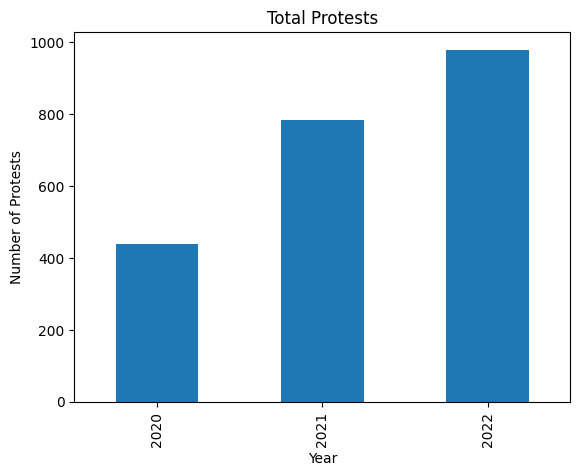

```python
# Grouping Years to find total number of observations
df_Counts = df_new.groupby('Year')['Year'].count()
display(df_Counts)
df_Counts.plot.bar(title='Total Protests', ylabel='Number of Protests')
```

This is certainlly the trend I was expected to see. Since lockdown was in 2020, it makes sense that 2020 would have the fewest protests. However, the escalation into 2021 and 2022 was much quicker than I anticipated.

| Year | EstimateLow | EstimateHigh |
| --- | --- | --- |
| 2020 | 60227 | 67773 |
| 2021 | 70483 | 126632 |
| 2022 | 145882 | 173236 |

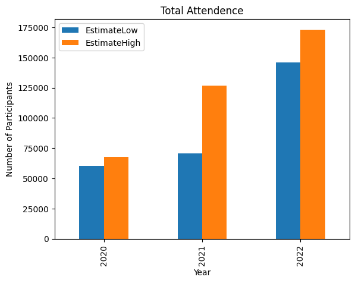

```python
# Grouping 'EstimateLow' and EstimateHigh and summing
df_estimate_sum = df_new.groupby('Year')[['EstimateLow', 'EstimateHigh']].sum()
display(df_estimate_sum)
df_estimate_sum.plot.bar(title='Total Attendence', ylabel='Number of Participants')
```

This trend is also not too interesting. People were very cautious of large gatherings in 2020 and were not quick to forget in 2021.

| Year | EstimateLow | EstimateHigh |
| --- | --- | --- |
| 2020 | 137.819222 | 155.086957 |
| 2021 | 90.131714 | 161.933504 |
| 2022 | 149.011236 | 176.951992 |

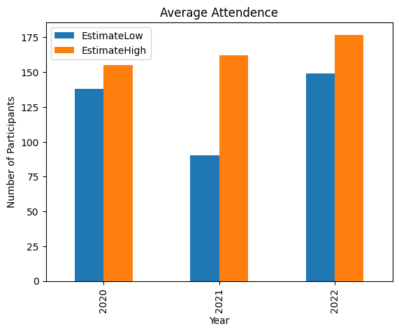

```python
# Grouping 'EstimateLow' and 'EstimateHigh' and averaging
df_estimate_avg = df_new.groupby('Year')[['EstimateLow', 'EstimateHigh']].mean()
display(df_estimate_avg)
df_estimate_avg.plot.bar(title='Average Attendence', ylabel='Number of Participants')
```

This is actually really interesting. The average attendence per protest in 2020 is rather equal to the attendence in the other years, if not more-so than 2021. Though lockdown seemed to affect the total number of protests and number of protestors, it did not seem to affect the average attendence.

Now I will be more closely investigating the relationship with overall protest numbers and their political affiliation over the years.

The first graph is a presentation of all of the protests within the full data table. That is, this is the total sum of protests and their political affiliation throughout the 3 years without taking into consideration the state. This seems lik a good place to start.

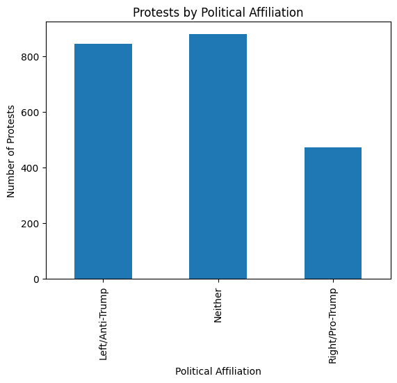

```python
# Creating bar graph of total protests throughout the 3 years
df_new['Political Affiliation'].value_counts(sort=False).plot.bar(title='Protests by Political Affiliation',
                                                                  ylabel='Number of Protests', xlabel='Political Affiliation')
```

The number of righ-leaning protests seem to be far fewer than left-leaning or non-affiliated protests. I wonder if that trend will remain consistent throughout individual states and how that stacks up against the hate crime statistics.

To investigate that trend during each year, I wll create a cross-tabulation including State and Political Affliation for 2020-2022 and display these results in a heatmap.

```python
# Creating three tables based on year
df_2020 = df_new.loc[df_new['Year'] == 2020]
df_2021 = df_new.loc[df_new['Year'] == 2021]
df_2022 = df_new.loc[df_new['Year'] == 2022]

# Creating three crosstab joint distributions
ct_2020 = pd.crosstab(df_2020.State, df_2020['Political Affiliation'], normalize=True)
ct_2021 = pd.crosstab(df_2021.State, df_2021['Political Affiliation'], normalize=True)
ct_2022 = pd.crosstab(df_2022.State, df_2022['Political Affiliation'], normalize=True)

# Displaying cross-tabulations
df_list = [ct_2020, ct_2021, ct_2022]
for df in df_list:
  display(df)
```

| Political Affiliation State | Left/Anti-Trump | Neither | Right/Pro-Trump |
| --- | --- | --- | --- |
| Alabama | 0.000000 | 0.000000 | 0.002294 |
| Alaska | 0.000000 | 0.002294 | 0.002294 |
| Arizona | 0.000000 | 0.009174 | 0.009174 |
| Arkansas | 0.000000 | 0.000000 | 0.004587 |
| California | 0.018349 | 0.064220 | 0.057339 |
| Colorado | 0.000000 | 0.004587 | 0.018349 |
| Connecticut | 0.002294 | 0.011468 | 0.013761 |
| District of Columbia | 0.002294 | 0.000000 | 0.000000 |
| Florida | 0.004587 | 0.027523 | 0.029817 |
| Georgia | 0.000000 | 0.011468 | 0.002294 |
| Hawaii | 0.002294 | 0.000000 | 0.000000 |
| Idaho | 0.000000 | 0.000000 | 0.009174 |
| Illinois | 0.000000 | 0.020642 | 0.011468 |
| Indiana | 0.000000 | 0.004587 | 0.018349 |
| Iowa | 0.000000 | 0.004587 | 0.004587 |
| Kansas | 0.000000 | 0.006881 | 0.004587 |
| Kentucky | 0.000000 | 0.000000 | 0.006881 |
| Louisiana | 0.000000 | 0.011468 | 0.002294 |
| Maine | 0.002294 | 0.006881 | 0.000000 |
| Maryland | 0.004587 | 0.016055 | 0.006881 |
| Massachusetts | 0.002294 | 0.016055 | 0.013761 |
| Michigan | 0.002294 | 0.013761 | 0.013761 |
| Minnesota | 0.000000 | 0.006881 | 0.006881 |
| Mississippi | 0.000000 | 0.002294 | 0.000000 |
| Missouri | 0.000000 | 0.016055 | 0.009174 |
| Montana | 0.000000 | 0.000000 | 0.004587 |
| Nebraska | 0.000000 | 0.000000 | 0.002294 |
| Nevada | 0.000000 | 0.002294 | 0.004587 |
| New Hampshire | 0.000000 | 0.002294 | 0.004587 |
| New Jersey | 0.000000 | 0.009174 | 0.018349 |
| New Mexico | 0.000000 | 0.000000 | 0.013761 |
| New York | 0.000000 | 0.029817 | 0.043578 |
| North Carolina | 0.004587 | 0.004587 | 0.011468 |
| Ohio | 0.000000 | 0.004587 | 0.016055 |
| Oklahoma | 0.002294 | 0.000000 | 0.000000 |
| Oregon | 0.000000 | 0.011468 | 0.018349 |
| Pennsylvania | 0.004587 | 0.011468 | 0.027523 |
| Rhode Island | 0.000000 | 0.000000 | 0.002294 |
| South Carolina | 0.000000 | 0.011468 | 0.000000 |
| South Dakota | 0.000000 | 0.000000 | 0.002294 |
| Tennessee | 0.000000 | 0.006881 | 0.006881 |
| Texas | 0.004587 | 0.034404 | 0.027523 |
| Utah | 0.000000 | 0.011468 | 0.009174 |
| Vermont | 0.000000 | 0.000000 | 0.009174 |
| Virginia | 0.004587 | 0.016055 | 0.013761 |
| Washington | 0.002294 | 0.004587 | 0.018349 |
| West Virginia | 0.000000 | 0.002294 | 0.004587 |
| Wisconsin | 0.000000 | 0.009174 | 0.000000 |

| Political Affiliation State | Left/Anti-Trump | Neither | Right/Pro-Trump |
| --- | --- | --- | --- |
| Alabama | 0.005115 | 0.003836 | 0.001279 |
| Alaska | 0.000000 | 0.001279 | 0.000000 |
| Arizona | 0.003836 | 0.002558 | 0.002558 |
| Arkansas | 0.002558 | 0.001279 | 0.000000 |
| California | 0.052430 | 0.040921 | 0.038363 |
| Colorado | 0.007673 | 0.000000 | 0.005115 |
| Connecticut | 0.005115 | 0.006394 | 0.006394 |
| Delaware | 0.001279 | 0.001279 | 0.000000 |
| District of Columbia | 0.015345 | 0.015345 | 0.002558 |
| Florida | 0.010230 | 0.089514 | 0.010230 |
| Georgia | 0.005115 | 0.005115 | 0.005115 |
| Hawaii | 0.006394 | 0.006394 | 0.003836 |
| Idaho | 0.002558 | 0.002558 | 0.005115 |
| Illinois | 0.015345 | 0.016624 | 0.003836 |
| Indiana | 0.010230 | 0.003836 | 0.002558 |
| Iowa | 0.002558 | 0.000000 | 0.001279 |
| Kansas | 0.001279 | 0.001279 | 0.000000 |
| Kentucky | 0.005115 | 0.003836 | 0.000000 |
| Louisiana | 0.001279 | 0.006394 | 0.001279 |
| Maine | 0.007673 | 0.001279 | 0.002558 |
| Maryland | 0.008951 | 0.007673 | 0.000000 |
| Massachusetts | 0.017903 | 0.015345 | 0.003836 |
| Michigan | 0.003836 | 0.006394 | 0.008951 |
| Minnesota | 0.023018 | 0.003836 | 0.005115 |
| Mississippi | 0.001279 | 0.001279 | 0.000000 |
| Missouri | 0.003836 | 0.005115 | 0.003836 |
| Montana | 0.001279 | 0.001279 | 0.003836 |
| Nebraska | 0.001279 | 0.003836 | 0.000000 |
| Nevada | 0.001279 | 0.002558 | 0.005115 |
| New Hampshire | 0.005115 | 0.000000 | 0.001279 |
| New Jersey | 0.008951 | 0.001279 | 0.001279 |
| New Mexico | 0.000000 | 0.000000 | 0.005115 |
| New York | 0.040921 | 0.052430 | 0.008951 |
| North Carolina | 0.014066 | 0.006394 | 0.015345 |
| North Dakota | 0.000000 | 0.000000 | 0.001279 |
| Ohio | 0.014066 | 0.007673 | 0.005115 |
| Oklahoma | 0.001279 | 0.002558 | 0.000000 |
| Oregon | 0.005115 | 0.002558 | 0.007673 |
| Pennsylvania | 0.024297 | 0.012788 | 0.010230 |
| Puerto Rico | 0.001279 | 0.000000 | 0.000000 |
| Rhode Island | 0.002558 | 0.001279 | 0.001279 |
| South Carolina | 0.002558 | 0.002558 | 0.000000 |
| South Dakota | 0.001279 | 0.001279 | 0.002558 |
| Tennessee | 0.003836 | 0.007673 | 0.001279 |
| Texas | 0.019182 | 0.026854 | 0.003836 |
| Utah | 0.000000 | 0.002558 | 0.000000 |
| Virginia | 0.014066 | 0.007673 | 0.010230 |
| Washington | 0.010230 | 0.001279 | 0.002558 |
| West Virginia | 0.002558 | 0.000000 | 0.001279 |
| Wisconsin | 0.003836 | 0.005115 | 0.000000 |

| Political Affiliation State | Left/Anti-Trump | Neither | Right/Pro-Trump |
| --- | --- | --- | --- |
| Alabama | 0.010215 | 0.000000 | 0.000000 |
| Alaska | 0.006129 | 0.000000 | 0.002043 |
| Arizona | 0.004086 | 0.001021 | 0.005107 |
| Arkansas | 0.004086 | 0.002043 | 0.001021 |
| California | 0.044944 | 0.081716 | 0.009193 |
| Colorado | 0.009193 | 0.001021 | 0.001021 |
| Connecticut | 0.004086 | 0.002043 | 0.000000 |
| Delaware | 0.002043 | 0.000000 | 0.000000 |
| District of Columbia | 0.025536 | 0.001021 | 0.006129 |
| Florida | 0.022472 | 0.003064 | 0.004086 |
| Georgia | 0.016343 | 0.003064 | 0.001021 |
| Guam | 0.001021 | 0.000000 | 0.000000 |
| Hawaii | 0.000000 | 0.003064 | 0.000000 |
| Idaho | 0.006129 | 0.000000 | 0.001021 |
| Illinois | 0.015322 | 0.043922 | 0.003064 |
| Indiana | 0.011236 | 0.001021 | 0.004086 |
| Iowa | 0.008172 | 0.031665 | 0.002043 |
| Kansas | 0.004086 | 0.023493 | 0.001021 |
| Kentucky | 0.006129 | 0.001021 | 0.000000 |
| Louisiana | 0.006129 | 0.000000 | 0.000000 |
| Maine | 0.004086 | 0.000000 | 0.000000 |
| Maryland | 0.010215 | 0.032686 | 0.001021 |
| Massachusetts | 0.013279 | 0.009193 | 0.004086 |
| Michigan | 0.012257 | 0.004086 | 0.001021 |
| Minnesota | 0.008172 | 0.003064 | 0.000000 |
| Mississippi | 0.001021 | 0.000000 | 0.000000 |
| Missouri | 0.011236 | 0.001021 | 0.000000 |
| Montana | 0.006129 | 0.000000 | 0.004086 |
| Nebraska | 0.004086 | 0.002043 | 0.002043 |
| Nevada | 0.002043 | 0.000000 | 0.001021 |
| New Hampshire | 0.001021 | 0.000000 | 0.002043 |
| New Jersey | 0.005107 | 0.002043 | 0.001021 |
| New Mexico | 0.006129 | 0.000000 | 0.001021 |
| New York | 0.037794 | 0.023493 | 0.009193 |
| North Carolina | 0.014300 | 0.005107 | 0.003064 |
| North Dakota | 0.002043 | 0.000000 | 0.001021 |
| Ohio | 0.034729 | 0.002043 | 0.005107 |
| Oklahoma | 0.006129 | 0.000000 | 0.000000 |
| Oregon | 0.006129 | 0.013279 | 0.001021 |
| Pennsylvania | 0.025536 | 0.008172 | 0.002043 |
| Puerto Rico | 0.001021 | 0.004086 | 0.000000 |
| Rhode Island | 0.000000 | 0.032686 | 0.000000 |
| South Carolina | 0.006129 | 0.001021 | 0.002043 |
| South Dakota | 0.003064 | 0.000000 | 0.000000 |
| Tennessee | 0.004086 | 0.002043 | 0.000000 |
| Texas | 0.019408 | 0.006129 | 0.005107 |
| Utah | 0.009193 | 0.000000 | 0.002043 |
| Vermont | 0.004086 | 0.000000 | 0.000000 |
| Virginia | 0.019408 | 0.003064 | 0.003064 |
| Washington | 0.004086 | 0.002043 | 0.000000 |
| West Virginia | 0.009193 | 0.000000 | 0.001021 |
| Wisconsin | 0.014300 | 0.031665 | 0.001021 |
| Wyoming | 0.003064 | 0.000000 | 0.002043 |

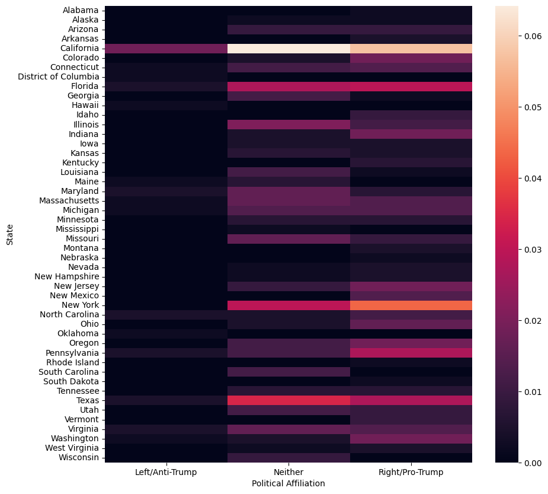

```python
# Creating the heatmap for 2020
plt.subplots(figsize=(10,10))
sns.heatmap(ct_2020, xticklabels=True, yticklabels=True)
```

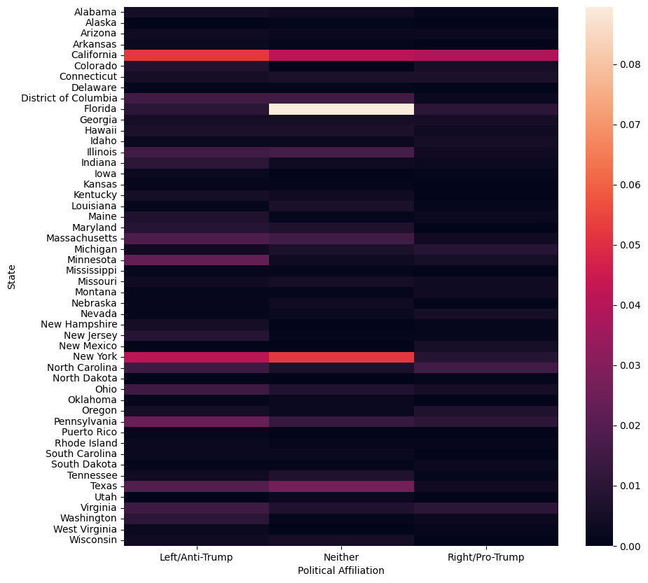

```python
# Creating the heatmap for 2021
plt.subplots(figsize=(10,10))
sns.heatmap(ct_2021, xticklabels=True, yticklabels=True)
```

There certainly seems to be a more even spread across political affiliation, possibly with the left-leaning/anti-Trump side being more present. It seems the shift I was anticipating has already begun.

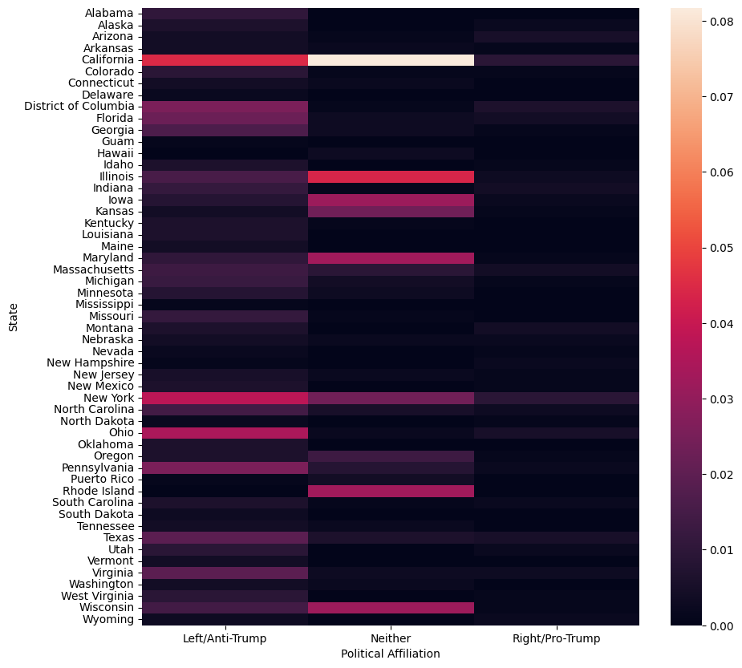

```python
# Creating the heatmap for 2022
plt.subplots(figsize=(10,10))
sns.heatmap(ct_2022, xticklabels=True, yticklabels=True)
```

And by 2022, protest political affiliation seems to be a mirror image of that in 2020. However, it is difficult to determine the intensity of the shift from a heatmap, so next I will create a conditional distribution of political affiliation given each state so that we can see which side is more dominant.

```python
# Creating full cross-tabulation
ct_full = pd.crosstab(df_new.State, df_new['Political Affiliation'], normalize=True)

# Creating conditional distribution
state_counts = ct_full.sum(axis=1)
pa_given_state = ct_full.divide(state_counts, axis=0)

# Displaying distribution
pa_given_state
```

| Political Affiliation State | Left/Anti-Trump | Neither | Right/Pro-Trump |
| --- | --- | --- | --- |
| Alabama | 0.736842 | 0.157895 | 0.105263 |
| Alaska | 0.545455 | 0.181818 | 0.272727 |
| Arizona | 0.280000 | 0.280000 | 0.440000 |
| Arkansas | 0.500000 | 0.250000 | 0.250000 |
| California | 0.313131 | 0.471380 | 0.215488 |
| Colorado | 0.483871 | 0.096774 | 0.419355 |
| Connecticut | 0.281250 | 0.375000 | 0.343750 |
| Delaware | 0.750000 | 0.250000 | 0.000000 |
| District of Columbia | 0.644068 | 0.220339 | 0.135593 |
| Florida | 0.225352 | 0.598592 | 0.176056 |
| Georgia | 0.526316 | 0.315789 | 0.157895 |
| Guam | 1.000000 | 0.000000 | 0.000000 |
| Hawaii | 0.352941 | 0.470588 | 0.176471 |
| Idaho | 0.421053 | 0.105263 | 0.473684 |
| Illinois | 0.262136 | 0.631068 | 0.106796 |
| Indiana | 0.487179 | 0.153846 | 0.358974 |
| Iowa | 0.208333 | 0.687500 | 0.104167 |
| Kansas | 0.142857 | 0.771429 | 0.085714 |
| Kentucky | 0.588235 | 0.235294 | 0.176471 |
| Louisiana | 0.368421 | 0.526316 | 0.105263 |
| Maine | 0.647059 | 0.235294 | 0.117647 |
| Maryland | 0.279412 | 0.661765 | 0.058824 |
| Massachusetts | 0.405797 | 0.405797 | 0.188406 |
| Michigan | 0.355556 | 0.333333 | 0.311111 |
| Minnesota | 0.619048 | 0.214286 | 0.166667 |
| Mississippi | 0.500000 | 0.500000 | 0.000000 |
| Missouri | 0.424242 | 0.363636 | 0.212121 |
| Montana | 0.411765 | 0.058824 | 0.529412 |
| Nebraska | 0.384615 | 0.384615 | 0.230769 |
| Nevada | 0.230769 | 0.230769 | 0.538462 |
| New Hampshire | 0.454545 | 0.090909 | 0.454545 |
| New Jersey | 0.413793 | 0.241379 | 0.344828 |
| New Mexico | 0.352941 | 0.000000 | 0.647059 |
| New York | 0.381215 | 0.425414 | 0.193370 |
| North Carolina | 0.457627 | 0.203390 | 0.338983 |
| North Dakota | 0.500000 | 0.000000 | 0.500000 |
| Ohio | 0.633803 | 0.140845 | 0.225352 |
| Oklahoma | 0.800000 | 0.200000 | 0.000000 |
| Oregon | 0.222222 | 0.444444 | 0.333333 |
| Pennsylvania | 0.505495 | 0.252747 | 0.241758 |
| Puerto Rico | 0.333333 | 0.666667 | 0.000000 |
| Rhode Island | 0.054054 | 0.891892 | 0.054054 |
| South Carolina | 0.444444 | 0.444444 | 0.111111 |
| South Dakota | 0.500000 | 0.125000 | 0.375000 |
| Tennessee | 0.318182 | 0.500000 | 0.181818 |
| Texas | 0.367347 | 0.428571 | 0.204082 |
| Utah | 0.409091 | 0.318182 | 0.272727 |
| Vermont | 0.500000 | 0.000000 | 0.500000 |
| Virginia | 0.492308 | 0.246154 | 0.261538 |
| Washington | 0.464286 | 0.178571 | 0.357143 |
| West Virginia | 0.687500 | 0.062500 | 0.250000 |
| Wisconsin | 0.298246 | 0.684211 | 0.017544 |
| Wyoming | 0.600000 | 0.000000 | 0.400000 |

To represent this data, I will use a stacked bar graph since it will display the proportions of political affiliation more clearly.

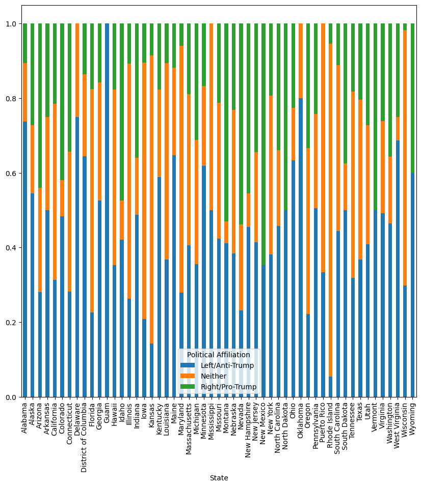

```python
# Creating stacked bar graph
pa_given_state.plot.bar(stacked=True, figsize=(10,10), legend=True)
```

With this and the first bar graph of political distribution over all three years, it is easy to determine that there was a large political shift in protests over the years. I am now wondering if such a shift will be consistent with an increase in hate crimes seeing as left-leaning protests tend to have more to do with social justice movements. Therefore, I am currently hypothesizing that since there has been a great increase in left-leaning/anti-Trump protests, there will also be a great increase in hate crimes across the U.S.

# Hate Crime Data

This data comes from the FBI Crime Data Explorer and is a depiction of each of the US states' reported hate crime incidents. The data I am using are the reports from 2020, 2021, and 2022. I would like to clarify that I am not reading in the original data that you would find on the website as that data was poorly formatted for reading into Pandas. Therefore, I copied the data into a new Excel file and formatted it in a way that could be read into Pandas. I also did not copy over extraneous data that I would not be using in this project.

The data can be found under the "Documents and Downloads" section of the front page. Link to data: https://cde.ucr.cjis.gov/LATEST/webapp/#/pages/downloads

## ETL

```python
# Changing directory
%cd ../'Hate Crimes'
```

```
/content/data_science/Project Data/Hate Crimes
```

As previously, the first step is to read in the files and see what we have to work with. From there, I can tidy and format the data.

```python
# Reading in files
hc_2020 = pd.read_csv('hate crimes by state 2020.csv')
hc_2021 = pd.read_csv('hate crimes by state 2021.csv')
hc_2022 = pd.read_csv('hate crimes by state 2022.csv')

# Let's see what we have
display(hc_2020.head(5))
display(hc_2021.head(5))
display(hc_2022.head(5))
```

|  | Participating State | Total offenses |
| --- | --- | --- |
| 0 | Alabama | 33 |
| 1 | Alaska | 10 |
| 2 | Arizona | 332 |
| 3 | Arkansas | 22 |
| 4 | California | 1537 |

|  | Participating State | Total offenses |
| --- | --- | --- |
| 0 | Alabama | 263 |
| 1 | Alaska | 14 |
| 2 | Arizona | 106 |
| 3 | Arkansas | 47 |
| 4 | California | 81 |

|  | Participating State | Total offenses |
| --- | --- | --- |
| 0 | Alabama | 254 |
| 1 | Alaska | 5 |
| 2 | Arizona | 225 |
| 3 | Arkansas | 38 |
| 4 | California | 2261 |

Everything looks good so far. Let's go ahead and add a year column for clarity and for future merging.

```python
# Creating a year column with appropriate years
hc_2020['Year'] = 2020
hc_2021['Year'] = 2021
hc_2022['Year'] = 2022

# Displaying
display(hc_2020.head(5))
display(hc_2021.head(5))
display(hc_2022.head(5))
```

|  | Participating State | Total offenses | Year |
| --- | --- | --- | --- |
| 0 | Alabama | 33 | 2020 |
| 1 | Alaska | 10 | 2020 |
| 2 | Arizona | 332 | 2020 |
| 3 | Arkansas | 22 | 2020 |
| 4 | California | 1537 | 2020 |

|  | Participating State | Total offenses | Year |
| --- | --- | --- | --- |
| 0 | Alabama | 263 | 2021 |
| 1 | Alaska | 14 | 2021 |
| 2 | Arizona | 106 | 2021 |
| 3 | Arkansas | 47 | 2021 |
| 4 | California | 81 | 2021 |

|  | Participating State | Total offenses | Year |
| --- | --- | --- | --- |
| 0 | Alabama | 254 | 2022 |
| 1 | Alaska | 5 | 2022 |
| 2 | Arizona | 225 | 2022 |
| 3 | Arkansas | 38 | 2022 |
| 4 | California | 2261 | 2022 |

I just want to chage the name of the 'Participating State' column to 'State' for clarity and brevity.

```python
# Creating list of dfs
df_list = [hc_2020, hc_2021, hc_2022]

# Renaming columns
for df in df_list:
  df.rename(columns={'Participating State': 'State'}, inplace=True)

# Displaying dfs
for df in df_list:
  display(df.head(1))
```

|  | State | Total offenses | Year |
| --- | --- | --- | --- |
| 0 | Alabama | 33 | 2020 |

|  | State | Total offenses | Year |
| --- | --- | --- | --- |
| 0 | Alabama | 263 | 2021 |

|  | State | Total offenses | Year |
| --- | --- | --- | --- |
| 0 | Alabama | 254 | 2022 |

Now that we have the three tables, I will go ahead and concatenate them.

```python
# Now we concatonate the data
hc_full = pd.concat([hc_2020, hc_2021, hc_2022])
hc_full
```

|  | State | Total offenses | Year |
| --- | --- | --- | --- |
| 0 | Alabama | 33 | 2020 |
| 1 | Alaska | 10 | 2020 |
| 2 | Arizona | 332 | 2020 |
| 3 | Arkansas | 22 | 2020 |
| 4 | California | 1537 | 2020 |
| ... | ... | ... | ... |
| 46 | Virginia | 211 | 2022 |
| 47 | Washington | 652 | 2022 |
| 48 | West Virginia | 59 | 2022 |
| 49 | Wisconsin | 163 | 2022 |
| 50 | Wyoming | 29 | 2022 |

153 rows × 3 columns

Now that we have a full dataframe, let's see what the dtypes are.

```python
# Dtypes look good
hc_full.dtypes
```

```
State             object
Total offenses     int64
Year               int64
dtype: object
```

Everything looks good.

## EDA

Now that we have our full table, let's look at some initial descriptive statistics.

```python
hc_full['Total offenses'].describe()
```

```
count     153.000000
mean      209.320261
std       285.948943
min         1.000000
25%        47.000000
50%       117.000000
75%       252.000000
max      2261.000000
Name: Total offenses, dtype: float64
```

That is a rather large jump from the 75th percentile to the max. I wonder if the data is messed up somehow.

```python
# Investigating the issue
hc_full.loc[hc_full['Total offenses'] == 2261]
```

|  | State | Total offenses | Year |
| --- | --- | --- | --- |
| 4 | California | 2261 | 2022 |

Even after looking at the original data, California just seems to be quite the outlier. I will need to keep this in mind for the analysis.

Next step is look closer into these offenses by state.

```python
# Grouping data by state and year
hc_group = hc_full.groupby(['State', 'Year'])['Total offenses'].sum()
hc_group
```

```
State      Year
Alabama    2020     33
           2021    263
           2022    254
Alaska     2020     10
           2021     14
                  ...
Wisconsin  2021    118
           2022    163
Wyoming    2020     21
           2021     21
           2022     29
Name: Total offenses, Length: 153, dtype: int64
```

That presentation doesn't help too much, so let's create a bar chart to help better understand what we are looking at.

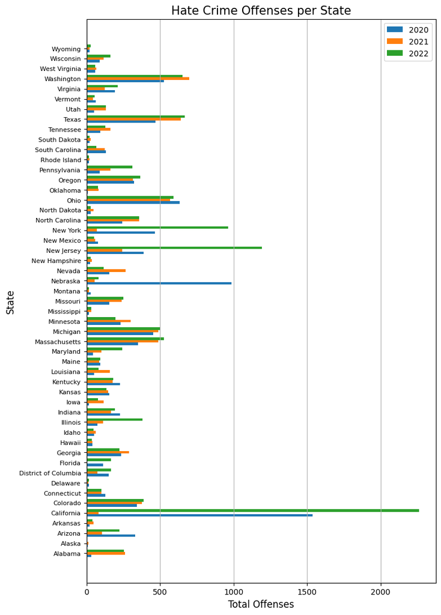

```python
# Creating numpy array
y_indexes = np.arange(51)
height = .25

# Setting figure size for the rather large plot
plt.figure(figsize=(8,13))

# Creating the plot
plt.barh(y_indexes - height, hc_2020['Total offenses'], height=height, label='2020')

plt.barh(y_indexes, hc_2021['Total offenses'], height=height, label='2021')

plt.barh(y_indexes + height, hc_2022['Total offenses'], height=height, label='2022')

# Matching the numpy array to correct labels
plt.yticks(ticks=y_indexes, labels=hc_2020['State'], fontsize=8)

# Adding title, axis labels, and legend
plt.title('Hate Crime Offenses per State', fontsize=15)
plt.xlabel('Total Offenses', fontsize=12)
plt.ylabel('State', fontsize=12)
plt.legend(prop={'size': 10})
plt.grid(axis='x')

# Displaying plot
plt.show()
```

Intersting, it doesn't seem like there is much of a pattern within hate crime distribution over the three years. Some states see increase, others decreases, and others sporadic jumps. This is not at all what I was expecting after seeing the distribution of protest political affiliation. This might make the construction of a model much more challenging.

# Modeling and Testing

The first step in creating a model will be to put everything into one table. To do so, I will simply merge the hate crime data and protest data together on State and Year.

```python
# Merging data
df_merged = df_new.merge(hc_full, on=['State', 'Year'])
df_merged
```

|  | State | EstimateLow | EstimateHigh | Political Affiliation | Year | Total offenses |
| --- | --- | --- | --- | --- | --- | --- |
| 0 | California | 100 | 100 | Left/Anti-Trump | 2020 | 1537 |
| 1 | California | 150 | 150 | Neither | 2020 | 1537 |
| 2 | California | 50 | 50 | Neither | 2020 | 1537 |
| 3 | California | 7 | 7 | Neither | 2020 | 1537 |
| 4 | California | 250 | 250 | Neither | 2020 | 1537 |
| ... | ... | ... | ... | ... | ... | ... |
| 2185 | North Dakota | 20 | 20 | Right/Pro-Trump | 2022 | 29 |
| 2186 | North Dakota | 50 | 50 | Left/Anti-Trump | 2022 | 29 |
| 2187 | Delaware | 30 | 50 | Left/Anti-Trump | 2022 | 16 |
| 2188 | Delaware | 50 | 50 | Left/Anti-Trump | 2022 | 16 |
| 2189 | Mississippi | 20 | 30 | Left/Anti-Trump | 2022 | 32 |

2190 rows × 6 columns

Next, to add a controlling variabel, I will be using state population data from 2020, 2021, and 2022. This data will be coming from the U.S. Census and, much like the hate crime data, will be poorly formatted for pandas. Therefore, I will not be using the originally formatted data, but a modified set. And again, the data itself was not modified, simply the formatting.

The original data can be found [here](https://www.census.gov/data/tables/time-series/demo/popest/2020s-state-total.html).

```python
# Changing directory
%cd ..

# Reading in population csv file
pop_df = pd.read_csv('Population Data.csv')
pop_df.head(5)
```

```
/content/data_science/Project Data
```

|  | State | 2020 | 2021 | 2022 |
| --- | --- | --- | --- | --- |
| 0 | Alabama | 5,031,362 | 5,049,846 | 5,074,296 |
| 1 | Alaska | 732,923 | 734,182 | 733,583 |
| 2 | Arizona | 7,179,943 | 7,264,877 | 7,359,197 |
| 3 | Arkansas | 3,014,195 | 3,028,122 | 3,045,637 |
| 4 | California | 39,501,653 | 39,142,991 | 39,029,342 |

Currently, the population for each year is under the column titled for that respective year. The first thing to do will be to create three seperate tables from this one, change the column name to population, add a year column to each, and concatenate the tabels back to one so that I can merge it with the above table.

```python
# Creating three seperate tabels by year
pop_df_2020 = pop_df[['State', '2020']]
pop_df_2021 = pop_df[['State', '2021']]
pop_df_2022 = pop_df[['State', '2022']]

# Adding a year column to each
pop_df_2020['Year'] = 2020
pop_df_2021['Year'] = 2021
pop_df_2022['Year'] = 2022

# Changing column name to Population
pop_df_2020.rename(columns={'2020': 'Population'}, inplace=True)
pop_df_2021.rename(columns={'2021': 'Population'}, inplace=True)
pop_df_2022.rename(columns={'2022': 'Population'}, inplace=True)

# Concatenating the dfs
pop_half = pd.concat([pop_df_2020, pop_df_2021])
pop_df = pd.concat([pop_half, pop_df_2022])
pop_df
```

[output not shown]

|  | State | Population | Year |
| --- | --- | --- | --- |
| 0 | Alabama | 5,031,362 | 2020 |
| 1 | Alaska | 732,923 | 2020 |
| 2 | Arizona | 7,179,943 | 2020 |
| 3 | Arkansas | 3,014,195 | 2020 |
| 4 | California | 39,501,653 | 2020 |
| ... | ... | ... | ... |
| 46 | Virginia | 8,683,619 | 2022 |
| 47 | Washington | 7,785,786 | 2022 |
| 48 | West Virginia | 1,775,156 | 2022 |
| 49 | Wisconsin | 5,892,539 | 2022 |
| 50 | Wyoming | 581,381 | 2022 |

153 rows × 3 columns

Now that I have created my new table, I can merge this with the previous full df.

```python
# Merging tables
final_df = df_merged.merge(pop_df, on=['State', 'Year'])
final_df
```

|  | State | EstimateLow | EstimateHigh | Political Affiliation | Year | Total offenses | Population |
| --- | --- | --- | --- | --- | --- | --- | --- |
| 0 | California | 100 | 100 | Left/Anti-Trump | 2020 | 1537 | 39,501,653 |
| 1 | California | 150 | 150 | Neither | 2020 | 1537 | 39,501,653 |
| 2 | California | 50 | 50 | Neither | 2020 | 1537 | 39,501,653 |
| 3 | California | 7 | 7 | Neither | 2020 | 1537 | 39,501,653 |
| 4 | California | 250 | 250 | Neither | 2020 | 1537 | 39,501,653 |
| ... | ... | ... | ... | ... | ... | ... | ... |
| 2185 | North Dakota | 20 | 20 | Right/Pro-Trump | 2022 | 29 | 779,261 |
| 2186 | North Dakota | 50 | 50 | Left/Anti-Trump | 2022 | 29 | 779,261 |
| 2187 | Delaware | 30 | 50 | Left/Anti-Trump | 2022 | 16 | 1,018,396 |
| 2188 | Delaware | 50 | 50 | Left/Anti-Trump | 2022 | 16 | 1,018,396 |
| 2189 | Mississippi | 20 | 30 | Left/Anti-Trump | 2022 | 32 | 2,940,057 |

2190 rows × 7 columns

With this final table, I can now begin creating my model. The first thing I will do is to simply train the model and test it on the training data alone. This should give me a baseline of how the model will look and perform.

```python
from sklearn.neighbors import KNeighborsRegressor
from sklearn.feature_extraction import DictVectorizer
from sklearn.preprocessing import StandardScaler

# Creating features to fit model
features = ['State', 'EstimateLow', 'EstimateHigh', 'Political Affiliation',
            'Year', 'Population']

# Setting the training data
X_train_dict = final_df[features].to_dict(orient="records")
y_train = final_df['Total offenses']

# Dummy encoding
vec = DictVectorizer(sparse=False)
vec.fit(X_train_dict)
X_train = vec.transform(X_train_dict)

# Scaling data
scaler = StandardScaler()
scaler.fit(X_train)
X_train_sc = scaler.transform(X_train)

# K-Nearest Neighbors Model
model = KNeighborsRegressor(n_neighbors=5)
model.fit(X_train_sc, y_train)
y_train_pred = model.predict(X_train_sc)

# Calculating prediction accuracy
mse = ((y_train - y_train_pred) ** 2).mean()
rmse = np.sqrt(mse)
rmse
```

```
147.59384928591015
```

It seems our current prediction is off by about 148 hate crime incidents in a year. Let's see what the average number of incidents is in a year.

```python
final_df['Total offenses'].mean()
```

```
411.8073059360731
```

So it seems that the model is currently off by over 25%. Not a great starting point. Let's start running some cross-validation tests to see if we can find a better K-value and tuning the model a bit more.

```python
# Creating a function to test the model based on features
def test_model(features):

  from sklearn.feature_extraction import DictVectorizer
  from sklearn.preprocessing import StandardScaler
  from sklearn.neighbors import KNeighborsRegressor
  from sklearn.pipeline import Pipeline
  from sklearn.model_selection import cross_val_score

  # Setting the training data
  X_dict = final_df[features].to_dict(orient="records")
  y = final_df['Total offenses']

  # Creating the pipeline for cv
  vec = DictVectorizer(sparse=False)
  scaler = StandardScaler()
  def get_cv_error(k):
      model = KNeighborsRegressor(n_neighbors=k)
      pipeline = Pipeline([("vectorizer", vec), ("scaler", scaler), ("fit", model)])
      mse = np.mean(-cross_val_score(
          pipeline, X_dict, y,
          cv=10, scoring="neg_mean_squared_error"
      ))
      # Finding and returning RMSE
      rmse = np.sqrt(mse)
      return rmse

  # Applying the function to a series of K-values to find the best match
  ks = pd.Series(range(1, 51))
  ks.index = range(1, 51)
  test_errs = ks.apply(get_cv_error)

  display(test_errs.sort_values())
```

First, I will just see what I have with running the model as-is.

```python
# Creating features to fit model
features = ['State', 'EstimateLow', 'EstimateHigh', 'Political Affiliation',
            'Year', 'Population']
test_model(features)
```

```
2     1308.478804
3     1309.808228
1     1311.358962
4     1313.637205
16    1313.680531
15    1313.694672
14    1314.657191
17    1315.000239
13    1317.226181
18    1317.403031
5     1318.106265
19    1319.245065
12    1320.801347
20    1321.432688
6     1323.723434
```

[output cut: 36 more lines]

```python
# Setting State to index and dropping California
final_df = final_df.set_index('State').drop('California')

# Resetting index
final_df = final_df.reset_index()
final_df
```

|  | State | EstimateLow | EstimateHigh | Political Affiliation | Year | Total offenses | Population |
| --- | --- | --- | --- | --- | --- | --- | --- |
| 0 | Oregon | 150 | 150 | Neither | 2020 | 324 | 4,244,795 |
| 1 | Oregon | 36 | 36 | Right/Pro-Trump | 2020 | 324 | 4,244,795 |
| 2 | Oregon | 100 | 100 | Neither | 2020 | 324 | 4,244,795 |
| 3 | Oregon | 200 | 300 | Right/Pro-Trump | 2020 | 324 | 4,244,795 |
| 4 | Oregon | 36 | 36 | Right/Pro-Trump | 2020 | 324 | 4,244,795 |
| ... | ... | ... | ... | ... | ... | ... | ... |
| 1888 | North Dakota | 20 | 20 | Right/Pro-Trump | 2022 | 29 | 779,261 |
| 1889 | North Dakota | 50 | 50 | Left/Anti-Trump | 2022 | 29 | 779,261 |
| 1890 | Delaware | 30 | 50 | Left/Anti-Trump | 2022 | 16 | 1,018,396 |
| 1891 | Delaware | 50 | 50 | Left/Anti-Trump | 2022 | 16 | 1,018,396 |
| 1892 | Mississippi | 20 | 30 | Left/Anti-Trump | 2022 | 32 | 2,940,057 |

1893 rows × 7 columns

With California out of the data, let's see what the error is now.

```python
# Creating features to fit model
features = ['State', 'EstimateLow', 'EstimateHigh', 'Political Affiliation',
            'Year', 'Population']

test_model(features)
```

```
1     202.281462
2     220.490351
3     233.627711
4     240.701775
5     245.742813
6     249.179314
7     252.304116
8     253.506376
10    254.003275
9     254.087586
11    254.187763
12    255.005329
17    255.689985
18    255.772137
16    256.126104
```

[output cut: 36 more lines]

```python
# Finding new mean without California
final_df['Total offenses'].mean()
```

```
263.62651875330164
```

That seems to be significantly better, but still not great as the prediction is still off by about 75%. Now I will start dropping some features to see if those are an issue.

```python
# Dropping Estimate numbers
features = ['State', 'Political Affiliation',
            'Year', 'Population']

test_model(features)
```

```
1     201.712462
2     219.637604
3     232.525221
4     239.885433
5     244.961057
6     248.779659
7     251.867976
10    253.138863
11    253.150450
8     253.254247
9     253.425539
12    253.941817
18    254.876959
13    255.005153
19    255.014155
```

[output cut: 36 more lines]

That really did nothing. Let's try again.

```python
# Dropping Political Affiliation
features = ['State', 'Year', 'Population']

test_model(features)
```

```
1     201.746776
2     218.804648
3     231.204409
4     238.419069
5     243.045434
6     246.303633
7     248.750718
8     250.660916
9     252.199084
10    253.468783
11    254.581780
12    255.592058
13    256.510428
14    257.343493
15    258.099415
```

[output cut: 36 more lines]

That didn't seem to help either.

```python
# Dropping Population
features = ['State', 'Political Affiliation',
            'Year']

test_model(features)
```

```
1     176.719099
2     186.955735
3     194.149532
4     199.610703
5     205.435103
6     211.485052
7     217.205319
8     220.823619
9     225.671020
10    230.686885
11    236.434390
12    242.400573
13    248.186382
14    253.774471
15    259.098702
```

[output cut: 36 more lines]

That might be the best I can get out of this model. I am not sure if I began by overfitting the model or if something was input incorrectly, but controlling for population seems to have an adverse effect on the model.

# Conclusions

From the above descriptive statistics and the models, there are a few conclusions we can confidently draw. First, there was a very large increase in protests overall from 2020 to 2022. Second, not only did the number of protests increase, but their political affiliation also shifted quite drastically towards the left. Third, hate crimes did not seem to uniformily increase across the nation as protest numbers and affiliation had. This is quite suprising as it would make sense that an increase in social justice movements would follow an increase in socially unacceptable crimes. And lastly, at least for this model, it seems as though there is no connection between hate crimes and protest numbers or affiliation.